Voltar

# Data Wrangling e Estatísticas Descritivas

Marina Bonatti

18/11/2021

#### **Objetivos** Juntar os bancos de dados ‘filmes’ e ‘series’, fornecidos pelo professor Wilson Tarantin durante a disciplina Data Wrangling II - MBA de Data Science e Analytics. Fazer uma limpeza dos dados, deixando apenas aqueles que considero relevantes para o meu objetivo. Comparar estatísticas descritivas envolvendo as plataformas de streaming (Netflix, Hulu, Prime Video e Disney) e o tipo de avaliação (Rotten Tomatoes e IMDb). Comecemos importando os bancos de dados. filmes <- read.csv("(6.2) Filmes Streaming.csv") series <- read.csv("(6.3) Séries Streaming.csv") Por motivos de contextualização, trago as seguintes informações: dim(filmes) ## [1] 9515 17 dim(series) ## [1] 5368 12 Assim, sabemos que o dataset ‘filmes’ contém 9515 observações e 17 variáveis, enquanto o dataset ‘series’ tem 5368 observações e 12 variáveis. Vamos dar uma olhada no nome das variáveis: names(filmes) ## [1] "X" "ID" "Title" "Year" ## [5] "Age" "IMDb" "Rotten.Tomatoes" "Netflix" ## [9] "Hulu" "Prime.Video" "Disney." "Type" ## [13] "Directors" "Genres" "Country" "Language" ## [17] "Runtime" names(series) ## [1] "X" "ID" "Title" "Year" ## [5] "Age" "IMDb" "Rotten.Tomatoes" "Netflix" ## [9] "Hulu" "Prime.Video" "Disney." "Type" Percebemos que das colunas 1 a 12 as duas bases de dados têm as mesmas variáveis. Por essa razão, conseguimos juntá-las facilmente: filmeseseries <- bind_rows(filmes[,1:12],series) A tradução desse código é: *R, junte as linhas dos datasets ‘filmes’ e ‘series’. Em ‘filmes’, no entanto, vamos utilizar apenas as colunas de 1 a 12.* Vamos visualizar como está nosso banco de dados ‘filmeseseries’ names(filmeseseries) ## [1] "X" "ID" "Title" "Year" ## [5] "Age" "IMDb" "Rotten.Tomatoes" "Netflix" ## [9] "Hulu" "Prime.Video" "Disney." "Type" dim(filmeseseries) ## [1] 14883 12 Ou seja, o que temos agora são todas as observações daquelas doze primeiras colunas que coincidem em ambos os bancos de dados. Para os propósitos do nosso projeto, as colunas X, Age e Year não têm serventia e, portanto, vamos tirá-las do nosso banco de dados. filmeseseries <- filmeseseries %>% select(-X, -Year, -Age) dim(filmeseseries) ## [1] 14883 9 Agora temos o dataset completo de filmes e séries. Além disso, tendo passado de 12 para 9 variáveis, conseguimos manter todas as informações relevantes para o nosso projeto e, ao mesmo, deixamos nosso banco de dados mais navegável! Repare que as notas do IMDb e do Rotten Tomatoes estão como character: class(filmeseseries$IMDb) ## [1] "character" class(filmeseseries$Rotten.Tomatoes) ## [1] "character" Isso é um problema na medida em que queremos usá-las para calcular estatísticas descritivas - como por exemplo média. Precisaremos ajustá-las. str(filmeseseries$Rotten.Tomatoes) ## chr [1:14883] "98/100" "97/100" "95/100" "94/100" "94/100" "94/100" ... Além disso, a variável Rotten.Tomatoes apresenta seus números com esse formato 98/100, 99/100. Isso também precisa ser alterado para que possamos calcular as estatísticas descritivas. ajuste_IMDB <- as.numeric(str_sub(filmeseseries$IMDb,1, 3)) ajuste_Rotten <- str_sub(filmeseseries$Rotten.Tomatoes, 1,3) sembarra <- gsub("/", "", ajuste_Rotten) sembarra <- as.numeric(sembarra, 1,3) filmeseseries <- mutate(filmeseseries, IMDb = ajuste_IMDB, Rotten.Tomatoes = sembarra) Com essa simples sequência de códigos, em primeiro lugar conseguimos transformar as duas variáveis IMDb e Rotten.Tomatoes em variáveis numéricas e, além disso, já atualizamos o banco de dados com essas alterações. *Note que tivemos que tirar as / de cada observação em Rotten.Tomatoes, caso contrário não teríamos conseguido transformá-la em numérica.* Vamos agora calcular as medidas descritivas para cada um dos nossos serviços de streaming. Para isso, preciso explicar como estão organizadas as variáveis Netflix, Hulu, Prime.Video e Disney. str(filmeseseries$Netflix) ## int [1:14883] 1 1 1 1 1 1 1 1 1 1 ... str(filmeseseries$Hulu) ## int [1:14883] 0 0 0 0 0 0 0 0 0 0 ... str(filmeseseries$Prime.Video) ## int [1:14883] 0 0 0 0 0 0 0 0 0 0 ... str(filmeseseries$Disney.) ## int [1:14883] 0 0 0 0 0 0 0 0 0 0 ... Percebem que a Netflix é a única variável que começa com uma sequência de vários 1? Isso acontece porque seus filmes estão listados primeiro nas observações. Nesse banco de dados, 1 significa que aquela plataforma (Netflix, Hulu, Prime Video ou Disney) tem determinada série ou filme, enquanto 0 significa que ela não tem. Por essa razão, quando formos calcular as estatísticas descritivas abaixo, primeiramente vamos filtrar apenas os filmes e séries que aquela determinada plataforma tem. Da seguinte maneira: netflix <- filter(filmeseseries, Netflix == 1) E, em seguida, calcularemos suas estatísticas descritivas: netflixdescritivas <- netflix %>% group_by(Type) %>% summarise(media_IMDB = mean(IMDb, na.rm = TRUE), media_Rotten = mean(Rotten.Tomatoes, na.rm = TRUE), maximo_IMDb = max(IMDb, na.rm = TRUE), min_IMDb = min(IMDb,na.rm = TRUE), maximo_Rotten = max(Rotten.Tomatoes,na.rm = TRUE), min_Rotten = min(Rotten.Tomatoes,na.rm = TRUE)) %>% ungroup () %>% droplevels(.) Faço uma breve explicação do código: R, crie um objeto chamado ‘netflixdescritivas’. Para compô-lo, use o dataset ‘netflix’ como base e agrupe as informações, tomando Type como parâmetro. (Abro um parênteses aqui para explicar que Type, nesse banco de dados, tem a seguinte formatação: 0 refere-se a filmes, enquanto 1 refere-se a séries) Após fazer isso, me dê as médias de IMDb e de Rotten, além de me dar o máximo e o mínimo de cada uma delas. Por fim, desagrupe o banco de dados que havia sido agrupado com base em Type. Vamos agora fazer o mesmo para as outras plataformas de streaming: hulu <- filter(filmeseseries, Hulu == 1) huludescritivas <- hulu %>% group_by(Type) %>% summarise(media_IMDB = mean(IMDb, na.rm = TRUE), media_Rotten = mean(Rotten.Tomatoes, na.rm = TRUE), maximo_IMDb = max(IMDb, na.rm = TRUE), min_IMDb = min(IMDb,na.rm = TRUE), maximo_Rotten = max(Rotten.Tomatoes,na.rm = TRUE), min_Rotten = min(Rotten.Tomatoes,na.rm = TRUE)) %>% ungroup () %>% droplevels(.) prime <- filter(filmeseseries, Prime.Video == 1) primedescritivas <- prime %>% group_by(Type) %>% summarise(media_IMDB = mean(IMDb, na.rm = TRUE), media_Rotten = mean(Rotten.Tomatoes, na.rm = TRUE), maximo_IMDb = max(IMDb, na.rm = TRUE), min_IMDb = min(IMDb,na.rm = TRUE), maximo_Rotten = max(Rotten.Tomatoes,na.rm = TRUE), min_Rotten = min(Rotten.Tomatoes,na.rm = TRUE)) %>% ungroup () %>% droplevels(.) disney <- filter(filmeseseries, Disney. == 1) disneydescritivas <- disney %>% group_by(Type) %>% summarise(media_IMDB = mean(IMDb, na.rm = TRUE), media_Rotten = mean(Rotten.Tomatoes, na.rm = TRUE), maximo_IMDb = max(IMDb, na.rm = TRUE), min_IMDb = min(IMDb,na.rm = TRUE), maximo_Rotten = max(Rotten.Tomatoes,na.rm = TRUE), min_Rotten = min(Rotten.Tomatoes,na.rm = TRUE)) %>% ungroup () %>% droplevels(.) Esses códigos seguem o mesmo padrão do que foi explicado acima! Agora, seria interessante juntarmos em um só todos esses bancos de dados de descritivas de cada plataforma: streaming <- c("Serviço", "Serviço") netflixdescritivas <- mutate(netflixdescritivas, streaming) huludescritivas <- mutate(huludescritivas, streaming) primedescritivas <- mutate(primedescritivas,streaming) disneydescritivas <- mutate(disneydescritivas,streaming) # Aqui vai entrar uma parte manual, que precisará ser capaz # de indicar qual o conteúdo de 'streaming' descritivasgeral <- bind_rows(netflixdescritivas, huludescritivas, primedescritivas,disneydescritivas) # O bom é que o bind_rows vai seguir a ordem que a gente pedir, então agora é só # mudar a variável streaming streamingfinal <- c("Netflix", "Netflix", "Hulu", "Hulu", "Prime Video", "Prime Video", "Disney", "Disney") # Agora só falta colocar o conteúdo dessa variável no lugar do conteúdo que está # em streaming descritivasgeral$streaming <- streamingfinal Explicando brevemente esse código: Criei uma variável streaming que continha duas vezes a palavra “Serviço”. Em seguida, adicionei essa variável em cada um dos dataframes de estatísticas descritivas que criamos acima. Em seguida, juntei as descritivas particulares em um dataframe apenas, chamado ‘descritivasgeral’. Por fim, alterei o conteúdo de streaming seguindo a ordem que havíamos utilizado para juntar cada banco de dados de estatísticas descritivas particulares (netflixdescritivas, huludescritivas,primedescritivas,disneydescritivas). Maravilha! Temos um banco de dados com todas as estatísticas descritivas que pedimos: str(descritivasgeral) ## tibble [8 x 8] (S3: tbl_df/tbl/data.frame) ## $ Type : int [1:8] 0 1 0 1 0 1 0 1 ## $ media_IMDB : num [1:8] 6.27 7.11 6.21 7.08 5.97 ... ## $ media_Rotten : num [1:8] 54.4 53.6 60.4 52.8 50.4 ... ## $ maximo_IMDb : num [1:8] 9 9.4 9 9.3 9.8 9.6 9.6 9.6 ## $ min_IMDb : num [1:8] 1.5 1.1 2.1 1.5 1.1 2.4 1.6 3.2 ## $ maximo_Rotten: num [1:8] 98 100 94 100 93 93 96 95 ## $ min_Rotten : num [1:8] 10 10 12 10 12 10 10 10 ## $ streaming : chr [1:8] "Netflix" "Netflix" "Hulu" "Hulu" ... Para finalizar, quero comparar cada descritiva em gráficos. Em primeiro lugar, quero que esses gráficos sejam organizados entre série e filme, então vou separá-los em dois dataframes diferentes: descritivasseries <- filter(descritivasgeral, Type == 1) descritivasfilmes <- filter(descritivasgeral, Type == 0) Comecemos pela comparação das médias de avaliações obtidas pelas séries e filmes de cada plataforma: **Com base nas notas IMDb**: # Média IMDb das séries ggplot() + geom_col(data = descritivasseries, aes(x = forcats::fct_reorder(streaming, media_IMDB), y = media_IMDB), fill = "seagreen1") + labs(title = "Avaliação das Séries", x = "", y = "Média das Notas IMDb") + coord_cartesian(ylim = c(6.85, 7.20)) O gráfico indica que, dentre as quatro médias de avaliações IMDb das séries presentes nos streaming analisados, a da Prime Video é a maior, enquanto a da Disney é a menor. #Média dos filmes: ggplot() + geom_col(data = descritivasfilmes, aes(x = forcats::fct_reorder(streaming, media_IMDB), y = media_IMDB), fill = "deepskyblue") + labs(title = "Avaliação dos Filmes", x = "", y = "Média das Notas IMDb") + coord_cartesian(ylim = c(5.85, 6.6)) Quanto à média das avaliações IMDb sobre os filmes presentes em cada streaming analisado, os filmes da Disney apresentam uma média de avaliações maior. Vejamos agora como ficam esses dois gráficos usando as médias da Rotten Tomatoes como parâmetro: ggplot() + geom_col(data = descritivasseries, aes(x = forcats::fct_reorder(streaming, media_Rotten), y = media_Rotten), fill = "seagreen1") + labs(title = "Avaliação das Séries", x = "", y = "Média das Notas Rotten Tomatoes")+ coord_cartesian(ylim = c(37, 55)) É extremamente curioso notar que, enquanto a média das avaliações das séries da Prime Video no IMDb é a mais alta, no Rotten Tomatoes ela é a mais baixa. ggplot() + geom_col(data = descritivasfilmes, aes(x = forcats::fct_reorder(streaming, media_Rotten), y = media_Rotten), fill = "deepskyblue") + labs(title = "Avaliação dos Filmes", x = "", y = "Média das Notas Rotten Tomatoes")+ coord_cartesian(ylim = c(50, 61)) A média das avaliações dos filmes também é bastante diferente quando comparamos IMDb e Rotten Tomatoes: No IMDb, as médias são: Prime Video < Hulu < Netflix < Disney. Já no Rotten Tomatoes, as médias são: Prime Video < Netflix < Disney < Hulu. Por fim, trago as notas mais altas obtidas por séries e filmes dentro de cada uma das plataformas: **Séries:** #Notas máximas séries IMDb ggplot() + geom_col(data = descritivasseries, aes(x = forcats::fct_reorder(streaming, maximo_IMDb), y = maximo_IMDb), fill = "seagreen1") + labs(title = "Avaliação das Séries", x = "", y = "Nota Máxima IMDb")+ coord_cartesian(ylim = c(9.2,9.7)) # Notas máximas séries Rotten ggplot() + geom_col(data = descritivasseries, aes(x = forcats::fct_reorder(streaming, maximo_Rotten), y = maximo_Rotten), fill = "seagreen1") + labs(title = "Avaliação das Séries", x = "", y = "Nota Máxima Rotten Tomatoes")+ coord_cartesian(ylim = c(92.75, 100)) As notas de IMDb mais altas obtidas por séries dentro das nossas plataformas analisadas foram notas 9.6, obtidas tanto em séries da Disney como em séries da Prime Video. Por curiosidade, vamos ver quais séries são essas? Começando pelo IMDb: filter(filmeseseries, Type == 1 & IMDb == 9.6) ## ID Title IMDb Rotten.Tomatoes Netflix Hulu ## 1 4054 The Secret World of Nature: Spain 9.6 51 0 0 ## 2 5401 Bluey 9.6 71 0 0 ## Prime.Video Disney. Type ## 1 1 0 1 ## 2 0 1 1 Assim, temos que as duas séries com as maiores notas IMDb no nosso banco de dados são: “The Secret World of Nature: Spain”, da Prime Video e “Bluey”, da Disney. E quanto às avaliações na Rotten Tomatoes? filter(filmeseseries, Type == 1 & Rotten.Tomatoes == 100) ## ID Title IMDb Rotten.Tomatoes Netflix Hulu Prime.Video Disney. ## 1 1 Breaking Bad 9.4 100 1 0 0 0 ## 2 1960 Rick and Morty 9.2 100 0 1 0 0 ## Type ## 1 1 ## 2 1 As maiores notas Rotten Tomatoes encontradas no nosso banco de dados foram obtidas pelas séries Breaking Bad (Netflix), e Rick and Morty (Hulu). **Filmes:** # Notas máximas filmes IMDb ggplot() + geom_col(data = descritivasfilmes, aes(x = forcats::fct_reorder(streaming,maximo_IMDb), y = maximo_IMDb), fill = "deepskyblue") + labs(title = "Avaliação dos Filmes", x = "", y = "Nota Máxima IMDb")+ coord_cartesian(ylim = c(8.9, 9.9)) ggplot() + geom_col(data = descritivasfilmes, aes(x = forcats::fct_reorder(streaming, maximo_Rotten), y = maximo_Rotten), fill = "deepskyblue") + labs(title = "Avaliação dos Filmes", x = "", y = "Nota Máxima Rotten Tomatoes")+ coord_cartesian(ylim = c(92.75, 98.5)) Quanto aos filmes, o filme dentro do nosso banco de dados que obteve a melhor nota IMDb está na plataforma Prime Video, enquanto que as avaliações Rotten Tomatoes dão a melhor nota para um filme pertencente à Netflix. Vamos descobrir que filmes são esses? filter(filmeseseries, Type == 0, IMDb > 9.75) ## ID Title IMDb Rotten.Tomatoes Netflix Hulu ## 1 6751 Ruby's Studio: the Feelings Show 9.8 47 0 0 ## Prime.Video Disney. Type ## 1 1 0 0 O filme melhor classificado no IMDb dentro do nosso banco de dados então é “Ruby’s Studio: the Feelings Show”, da Prime Video. filter(filmeseseries, Type == 0, Rotten.Tomatoes == 98 ) ## ID Title IMDb Rotten.Tomatoes Netflix Hulu Prime.Video Disney. Type ## 1 1 The Irishman 7.8 98 1 0 0 0 0 E o melhor avaliado no Rotten Tomatoes é “The Irishman”, da Netflix.

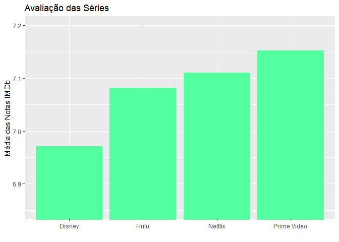

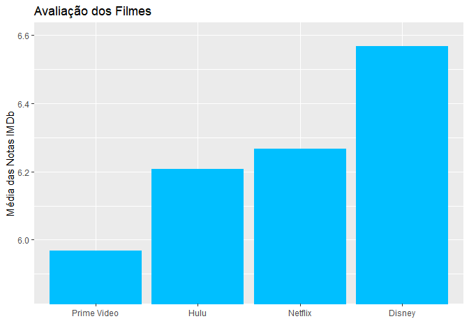

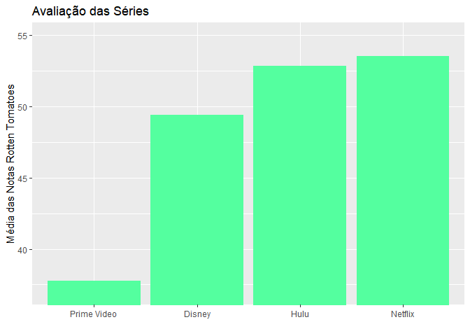

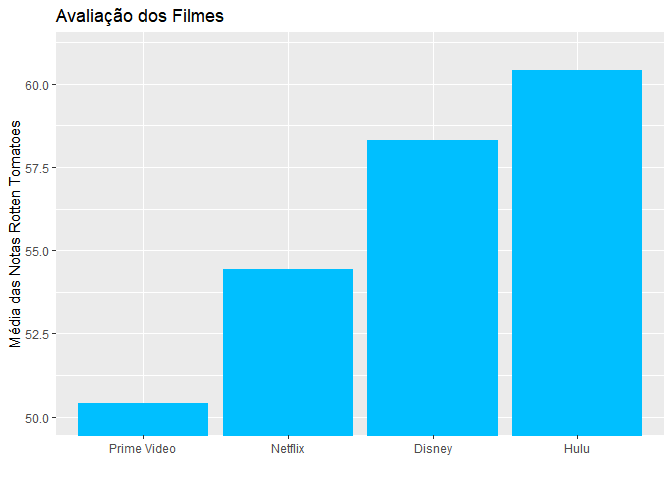

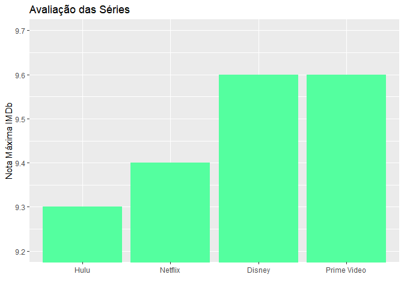

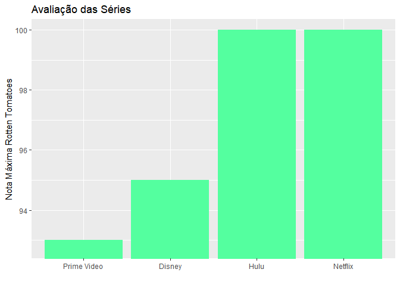

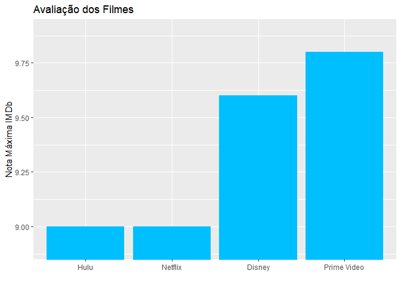

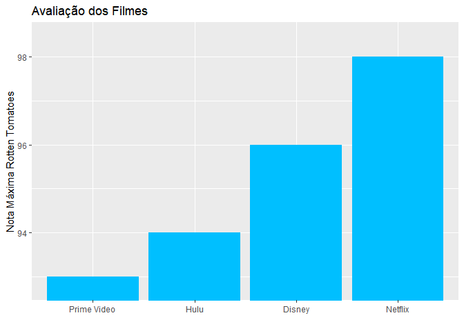